# IBM Python Statistics Project

### Name: Edeh Emeka Nweke

### Project: IBM Python Statistics Project

### Date: 17/09/2021

```python
import numpy as np
import pandas as pd
import matplotlib.pyplot as pyplot
import seaborn as sns
import scipy.stats
import statsmodels.api as sm
```

```python
boston_house = pd.read_csv('C:\\Users\\EDEH EMEKA NWEKE\Desktop\\boston_housing.csv')
```

```python
boston_house
```

|  | Unnamed: 0 | CRIM | ZN | INDUS | CHAS | NOX | RM | AGE | DIS | RAD | TAX | PTRATIO | LSTAT | MEDV |
| --- | --- | --- | --- | --- | --- | --- | --- | --- | --- | --- | --- | --- | --- | --- |
| 0 | 0 | 0.00632 | 18.0 | 2.31 | 0.0 | 0.538 | 6.575 | 65.2 | 4.0900 | 1.0 | 296.0 | 15.3 | 4.98 | 24.0 |
| 1 | 1 | 0.02731 | 0.0 | 7.07 | 0.0 | 0.469 | 6.421 | 78.9 | 4.9671 | 2.0 | 242.0 | 17.8 | 9.14 | 21.6 |
| 2 | 2 | 0.02729 | 0.0 | 7.07 | 0.0 | 0.469 | 7.185 | 61.1 | 4.9671 | 2.0 | 242.0 | 17.8 | 4.03 | 34.7 |
| 3 | 3 | 0.03237 | 0.0 | 2.18 | 0.0 | 0.458 | 6.998 | 45.8 | 6.0622 | 3.0 | 222.0 | 18.7 | 2.94 | 33.4 |
| 4 | 4 | 0.06905 | 0.0 | 2.18 | 0.0 | 0.458 | 7.147 | 54.2 | 6.0622 | 3.0 | 222.0 | 18.7 | 5.33 | 36.2 |
| ... | ... | ... | ... | ... | ... | ... | ... | ... | ... | ... | ... | ... | ... | ... |
| 501 | 501 | 0.06263 | 0.0 | 11.93 | 0.0 | 0.573 | 6.593 | 69.1 | 2.4786 | 1.0 | 273.0 | 21.0 | 9.67 | 22.4 |
| 502 | 502 | 0.04527 | 0.0 | 11.93 | 0.0 | 0.573 | 6.120 | 76.7 | 2.2875 | 1.0 | 273.0 | 21.0 | 9.08 | 20.6 |
| 503 | 503 | 0.06076 | 0.0 | 11.93 | 0.0 | 0.573 | 6.976 | 91.0 | 2.1675 | 1.0 | 273.0 | 21.0 | 5.64 | 23.9 |
| 504 | 504 | 0.10959 | 0.0 | 11.93 | 0.0 | 0.573 | 6.794 | 89.3 | 2.3889 | 1.0 | 273.0 | 21.0 | 6.48 | 22.0 |
| 505 | 505 | 0.04741 | 0.0 | 11.93 | 0.0 | 0.573 | 6.030 | 80.8 | 2.5050 | 1.0 | 273.0 | 21.0 | 7.88 | 11.9 |

506 rows × 14 columns

The following describes the dataset variables:  
· CRIM - per capita crime rate by town  
· ZN - proportion of residential land zoned for lots over 25,000 sq.ft.  
· INDUS - proportion of non-retail business acres per town.  
· CHAS - Charles River dummy variable (1 if tract bounds river; 0 otherwise)  
· NOX - nitric oxides concentration (parts per 10 million)  
· RM - average number of rooms per dwelling  
· AGE - proportion of owner-occupied units built prior to 1940  
· DIS - weighted distances to five Boston employment centres  
· RAD - index of accessibility to radial highways  
· TAX - full-value property-tax rate per 10,000 dollars  
· PTRATIO - pupil-teacher ratio by town  
· LSTAT - % lower status of the population  
· MEDV - Median value of owner-occupied homes in $1000's

Task 4: Generate Descriptive Statistics and Visualizations  
For all visualizations, please include a title in each graph and appropriate labels

Generate the following and explain your findings:

For the "Median value of owner-occupied homes" provide a boxplot

Provide a histogram for the Charles river variable

Provide a boxplot for the MEDV variable vs the AGE variable. (Discretize the age variable into three groups of 35 years and younger, between 35 and 70 years and 70 years and older)

Provide a scatter plot to show the relationship between Nitric oxide concentrations and the proportion of non-retail business acres per town. What can you say about the relationship?

Create a histogram for the pupil to teacher ratio variable

```python
boston_house.describe() #Produce a descriptive statistics table
```

|  | Unnamed: 0 | CRIM | ZN | INDUS | CHAS | NOX | RM | AGE | DIS | RAD | TAX | PTRATIO | LSTAT | MEDV |
| --- | --- | --- | --- | --- | --- | --- | --- | --- | --- | --- | --- | --- | --- | --- |
| count | 506.000000 | 506.000000 | 506.000000 | 506.000000 | 506.000000 | 506.000000 | 506.000000 | 506.000000 | 506.000000 | 506.000000 | 506.000000 | 506.000000 | 506.000000 | 506.000000 |
| mean | 252.500000 | 3.613524 | 11.363636 | 11.136779 | 0.069170 | 0.554695 | 6.284634 | 68.574901 | 3.795043 | 9.549407 | 408.237154 | 18.455534 | 12.653063 | 22.532806 |
| std | 146.213884 | 8.601545 | 23.322453 | 6.860353 | 0.253994 | 0.115878 | 0.702617 | 28.148861 | 2.105710 | 8.707259 | 168.537116 | 2.164946 | 7.141062 | 9.197104 |
| min | 0.000000 | 0.006320 | 0.000000 | 0.460000 | 0.000000 | 0.385000 | 3.561000 | 2.900000 | 1.129600 | 1.000000 | 187.000000 | 12.600000 | 1.730000 | 5.000000 |
| 25% | 126.250000 | 0.082045 | 0.000000 | 5.190000 | 0.000000 | 0.449000 | 5.885500 | 45.025000 | 2.100175 | 4.000000 | 279.000000 | 17.400000 | 6.950000 | 17.025000 |
| 50% | 252.500000 | 0.256510 | 0.000000 | 9.690000 | 0.000000 | 0.538000 | 6.208500 | 77.500000 | 3.207450 | 5.000000 | 330.000000 | 19.050000 | 11.360000 | 21.200000 |
| 75% | 378.750000 | 3.677083 | 12.500000 | 18.100000 | 0.000000 | 0.624000 | 6.623500 | 94.075000 | 5.188425 | 24.000000 | 666.000000 | 20.200000 | 16.955000 | 25.000000 |
| max | 505.000000 | 88.976200 | 100.000000 | 27.740000 | 1.000000 | 0.871000 | 8.780000 | 100.000000 | 12.126500 | 24.000000 | 711.000000 | 22.000000 | 37.970000 | 50.000000 |

### Boxplot for "Median value of owner-occupied homes"

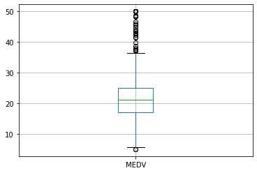

```python
boxplot = boston_house.boxplot(column=['MEDV'])
```

### Histogram for CHAS

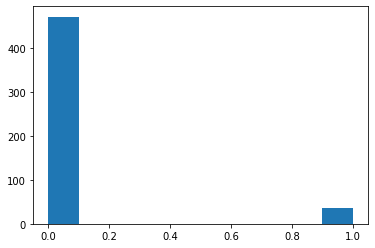

```python
pyplot.hist(boston_house['CHAS'])
```

```python
younger_35 = boston_house.loc[boston_house.AGE <=35 ]
#age variable groups of 35 years or younger
```

```python
younger_35
```

|  | Unnamed: 0 | CRIM | ZN | INDUS | CHAS | NOX | RM | AGE | DIS | RAD | TAX | PTRATIO | LSTAT | MEDV |
| --- | --- | --- | --- | --- | --- | --- | --- | --- | --- | --- | --- | --- | --- | --- |
| 16 | 16 | 1.05393 | 0.0 | 8.14 | 0.0 | 0.538 | 5.935 | 29.3 | 4.4986 | 4.0 | 307.0 | 21.0 | 6.58 | 23.1 |
| 38 | 38 | 0.17505 | 0.0 | 5.96 | 0.0 | 0.499 | 5.966 | 30.2 | 3.8473 | 5.0 | 279.0 | 19.2 | 10.13 | 24.7 |
| 39 | 39 | 0.02763 | 75.0 | 2.95 | 0.0 | 0.428 | 6.595 | 21.8 | 5.4011 | 3.0 | 252.0 | 18.3 | 4.32 | 30.8 |
| 40 | 40 | 0.03359 | 75.0 | 2.95 | 0.0 | 0.428 | 7.024 | 15.8 | 5.4011 | 3.0 | 252.0 | 18.3 | 1.98 | 34.9 |
| 41 | 41 | 0.12744 | 0.0 | 6.91 | 0.0 | 0.448 | 6.770 | 2.9 | 5.7209 | 3.0 | 233.0 | 17.9 | 4.84 | 26.6 |
| ... | ... | ... | ... | ... | ... | ... | ... | ... | ... | ... | ... | ... | ... | ... |
| 349 | 349 | 0.02899 | 40.0 | 1.25 | 0.0 | 0.429 | 6.939 | 34.5 | 8.7921 | 1.0 | 335.0 | 19.7 | 5.89 | 26.6 |
| 352 | 352 | 0.07244 | 60.0 | 1.69 | 0.0 | 0.411 | 5.884 | 18.5 | 10.7103 | 4.0 | 411.0 | 18.3 | 7.79 | 18.6 |
| 354 | 354 | 0.04301 | 80.0 | 1.91 | 0.0 | 0.413 | 5.663 | 21.9 | 10.5857 | 4.0 | 334.0 | 22.0 | 8.05 | 18.2 |
| 355 | 355 | 0.10659 | 80.0 | 1.91 | 0.0 | 0.413 | 5.936 | 19.5 | 10.5857 | 4.0 | 334.0 | 22.0 | 5.57 | 20.6 |
| 495 | 495 | 0.17899 | 0.0 | 9.69 | 0.0 | 0.585 | 5.670 | 28.8 | 2.7986 | 6.0 | 391.0 | 19.2 | 17.60 | 23.1 |

91 rows × 14 columns

```python
younger_70 = boston_house.loc[(boston_house.AGE >35) & (boston_house.AGE <70) ]
#age variable groups older than 35 years but younger than 70 years
```

```python
younger_70
```

|  | Unnamed: 0 | CRIM | ZN | INDUS | CHAS | NOX | RM | AGE | DIS | RAD | TAX | PTRATIO | LSTAT | MEDV |
| --- | --- | --- | --- | --- | --- | --- | --- | --- | --- | --- | --- | --- | --- | --- |
| 0 | 0 | 0.00632 | 18.0 | 2.31 | 0.0 | 0.538 | 6.575 | 65.2 | 4.0900 | 1.0 | 296.0 | 15.3 | 4.98 | 24.0 |
| 2 | 2 | 0.02729 | 0.0 | 7.07 | 0.0 | 0.469 | 7.185 | 61.1 | 4.9671 | 2.0 | 242.0 | 17.8 | 4.03 | 34.7 |
| 3 | 3 | 0.03237 | 0.0 | 2.18 | 0.0 | 0.458 | 6.998 | 45.8 | 6.0622 | 3.0 | 222.0 | 18.7 | 2.94 | 33.4 |
| 4 | 4 | 0.06905 | 0.0 | 2.18 | 0.0 | 0.458 | 7.147 | 54.2 | 6.0622 | 3.0 | 222.0 | 18.7 | 5.33 | 36.2 |
| 5 | 5 | 0.02985 | 0.0 | 2.18 | 0.0 | 0.458 | 6.430 | 58.7 | 6.0622 | 3.0 | 222.0 | 18.7 | 5.21 | 28.7 |
| ... | ... | ... | ... | ... | ... | ... | ... | ... | ... | ... | ... | ... | ... | ... |
| 487 | 487 | 4.83567 | 0.0 | 18.10 | 0.0 | 0.583 | 5.905 | 53.2 | 3.1523 | 24.0 | 666.0 | 20.2 | 11.45 | 20.6 |
| 493 | 493 | 0.17331 | 0.0 | 9.69 | 0.0 | 0.585 | 5.707 | 54.0 | 2.3817 | 6.0 | 391.0 | 19.2 | 12.01 | 21.8 |
| 494 | 494 | 0.27957 | 0.0 | 9.69 | 0.0 | 0.585 | 5.926 | 42.6 | 2.3817 | 6.0 | 391.0 | 19.2 | 13.59 | 24.5 |
| 498 | 498 | 0.23912 | 0.0 | 9.69 | 0.0 | 0.585 | 6.019 | 65.3 | 2.4091 | 6.0 | 391.0 | 19.2 | 12.92 | 21.2 |
| 501 | 501 | 0.06263 | 0.0 | 11.93 | 0.0 | 0.573 | 6.593 | 69.1 | 2.4786 | 1.0 | 273.0 | 21.0 | 9.67 | 22.4 |

128 rows × 14 columns

```python
older_70 = boston_house.loc[boston_house.AGE >70 ]
older_70
#age variable groups older than 70 years
```

|  | Unnamed: 0 | CRIM | ZN | INDUS | CHAS | NOX | RM | AGE | DIS | RAD | TAX | PTRATIO | LSTAT | MEDV |
| --- | --- | --- | --- | --- | --- | --- | --- | --- | --- | --- | --- | --- | --- | --- |
| 1 | 1 | 0.02731 | 0.0 | 7.07 | 0.0 | 0.469 | 6.421 | 78.9 | 4.9671 | 2.0 | 242.0 | 17.8 | 9.14 | 21.6 |
| 7 | 7 | 0.14455 | 12.5 | 7.87 | 0.0 | 0.524 | 6.172 | 96.1 | 5.9505 | 5.0 | 311.0 | 15.2 | 19.15 | 27.1 |
| 8 | 8 | 0.21124 | 12.5 | 7.87 | 0.0 | 0.524 | 5.631 | 100.0 | 6.0821 | 5.0 | 311.0 | 15.2 | 29.93 | 16.5 |
| 9 | 9 | 0.17004 | 12.5 | 7.87 | 0.0 | 0.524 | 6.004 | 85.9 | 6.5921 | 5.0 | 311.0 | 15.2 | 17.10 | 18.9 |
| 10 | 10 | 0.22489 | 12.5 | 7.87 | 0.0 | 0.524 | 6.377 | 94.3 | 6.3467 | 5.0 | 311.0 | 15.2 | 20.45 | 15.0 |
| ... | ... | ... | ... | ... | ... | ... | ... | ... | ... | ... | ... | ... | ... | ... |
| 500 | 500 | 0.22438 | 0.0 | 9.69 | 0.0 | 0.585 | 6.027 | 79.7 | 2.4982 | 6.0 | 391.0 | 19.2 | 14.33 | 16.8 |
| 502 | 502 | 0.04527 | 0.0 | 11.93 | 0.0 | 0.573 | 6.120 | 76.7 | 2.2875 | 1.0 | 273.0 | 21.0 | 9.08 | 20.6 |
| 503 | 503 | 0.06076 | 0.0 | 11.93 | 0.0 | 0.573 | 6.976 | 91.0 | 2.1675 | 1.0 | 273.0 | 21.0 | 5.64 | 23.9 |
| 504 | 504 | 0.10959 | 0.0 | 11.93 | 0.0 | 0.573 | 6.794 | 89.3 | 2.3889 | 1.0 | 273.0 | 21.0 | 6.48 | 22.0 |
| 505 | 505 | 0.04741 | 0.0 | 11.93 | 0.0 | 0.573 | 6.030 | 80.8 | 2.5050 | 1.0 | 273.0 | 21.0 | 7.88 | 11.9 |

287 rows × 14 columns

### Boxplot for the MEDV variable vs the AGE variable

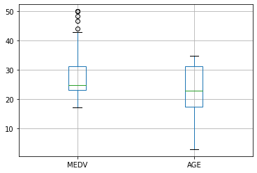

```python
MEDV_vs_Age_under35 = younger_35.boxplot(column=['MEDV','AGE'])
```

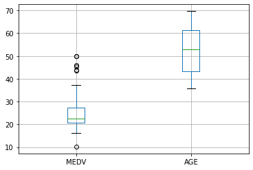

```python
MEDV_vs_Age_btw35and70 = younger_70.boxplot(column=['MEDV','AGE'])
```

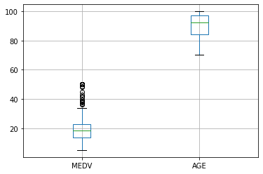

```python
MEDV_vs_Age_older70 = older_70.boxplot(column=['MEDV','AGE'])
```

### scatter plot to show the relationship between Nitric oxide concentrations and the proportion of non-retail business acres per town

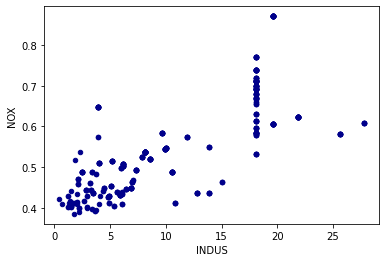

```python
scatter = boston_house.plot.scatter(x='INDUS',
                      y='NOX',
                      c='DarkBlue')
```

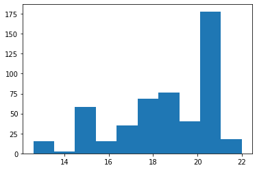

```python
pyplot.hist(boston_house['PTRATIO'])
```

The above distribution has a negative skewness where the median is larger than the mean

## Task 5: Use the appropriate tests to answer the questions provided.

For each of the following questions;

Is there a significant difference in median value of houses bounded by the Charles river or not? (T-test for independent samples)

Is there a difference in Median values of houses (MEDV) for each proportion of owner occupied units built prior to 1940 (AGE)? (ANOVA)

Can we conclude that there is no relationship between Nitric oxide concentrations and proportion of non-retail business acres per town? (Pearson Correlation)

What is the impact of an additional weighted distance to the five Boston employment centres on the median value of owner occupied homes? (Regression analysis)

Be sure to:

State your hypothesis.

Use α = 0.05

Perform the test Statistics.

State the conclusion from the test.

## No. 1 T-Test:

Using the Boston Housing Data We need to check if there a significant difference in median value of houses bounded by the Charles river or not?  
ASSUMPTIONS -

t-test will be used for independent samples. For the independent t-test, the following assumptions must be met.

One independent, categorical variable with two levels or group.  
One dependent continuous variable.  
Independence of the observations. Each subject should belong to only one group. There is no relationship between the observations in each group.  
The dependent variable must follow a normal distribution  
Assumption of homogeneity of variance

### Hypothesis

H0:µ1=µ2 ("there is no difference in median value of houses bounded by the Charles river")  
H1:µ1≠µ2 ("there is a difference in median value of houses bounded by the Charles river")

Using the ttest_ind from the scipy_stats library

```python
ttest = scipy.stats.ttest_ind(boston_house['MEDV'], boston_house['CHAS'])
ttest
```

```
Ttest_indResult(statistic=54.9210289745203, pvalue=1.4651540072350996e-305)
```

## No. 2 ANOVA:

If there is a difference in Median values of houses (MEDV) for each proportion of owner occupied units built prior to 1940 (AGE).  
First, we group the data into different age categories as the one-way ANOVA can't work with continuous variable.

```python
boston_house.loc[boston_house['AGE'] <= 30, 'Age_Group'] = "35 & younger"
boston_house.loc[(boston_house['AGE'] > 30) & (boston_house['AGE'] < 70), 'Age_Group'] = "Between 35 & 70"
boston_house.loc[(boston_house['AGE'] >= 70), 'Age_Group'] = "70 & older"
```

### Hypothesis

H0:µ1=µ2=µ3 (the three population medians are equal)  
H1: At least one of the medians differ

```python
#Test for equality of variance. I will use Levene’s test to check the assumption of
#equal variances before running a One-Way ANOVA test.
scipy.stats.levene(boston_house[boston_house['Age_Group'] == "35 & younger"]['MEDV'],
                   boston_house[boston_house['Age_Group'] == "Between 35 & 70"]['MEDV'],
                   boston_house[boston_house['Age_Group'] == "70 & older"]['MEDV'],
                   center='median')
```

```
LeveneResult(statistic=2.767459169827219, pvalue=0.06377821200332309)
```

### Interpretation

Since the p-value is larger than the alpha level(0.05), then i can say that the null hypothesis stands —  
that the variances are equal. For the purpose of this exercise, i will continue with analysis.

To run the One-Way ANOVA test, First, i will separate the three samples (one for each category) into three variables.

```python
younger_35 = boston_house[boston_house['Age_Group'] == "35 & younger"]['MEDV']
younger_70 = boston_house[boston_house['Age_Group'] == "Between 35 & 70"]['MEDV']
older_70 = boston_house[boston_house['Age_Group'] == "70 & older"]['MEDV']
```

```python
scipy.stats.f_oneway(younger_35, younger_70, older_70)
```

```
F_onewayResult(statistic=34.249179272635395, pvalue=1.135217093487225e-14)
```

### Conclusion:

Since the p-value is less than 0.05, we will reject the null hypothesis as there is significant evidence that at least one of the medians differ.

## No. 3 Pearson Correlation

Can we conclude that there is no relationship between Nitric oxide concentrations and proportion of non-retail business acres per town?

### Hypothesis:

H0: There is no relationship between Nitric oxide concentrations and proportion of non-retail business acres per town.  
H1: There is a relationship between Nitric oxide concentrations and proportion of non-retail business acres per town.

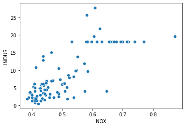

```python
ax = sns.scatterplot(x="NOX", y="INDUS", data=boston_house)
```

```python
scipy.stats.pearsonr(boston_house['INDUS'], boston_house['NOX'])
```

```
(0.7636514469209154, 7.913361061236894e-98)
```

## No. 4 Regression analysis

What is the impact of an additional weighted distance to the five Boston employment centres on the median value of owner occupied homes?

### Hypothesis:

𝐻0 = additional weighted distance to the five Boston employment centres has no impact on the median value of owner occupied homes  
𝐻1 = additional weighted distance to the five Boston employment centres has an impact on the median value of owner occupied homes

```python
## X is the input variables (or independent variables)
X = boston_house['DIS']
## y is the target/dependent variable
y = boston_house['MEDV']
## add an intercept (beta_0) to our model
X = sm.add_constant(X)

model = sm.OLS(y, X).fit()
predictions = model.predict(X)

# Print out the statistics
model.summary()
```

OLS Regression Results

| Dep. Variable: | MEDV | R-squared: | 0.062 |
| --- | --- | --- | --- |
| Model: | OLS | Adj. R-squared: | 0.061 |
| Method: | Least Squares | F-statistic: | 33.58 |
| Date: | Sun, 19 Sep 2021 | Prob (F-statistic): | 1.21e-08 |
| Time: | 11:24:24 | Log-Likelihood: | -1823.9 |
| No. Observations: | 506 | AIC: | 3652. |
| Df Residuals: | 504 | BIC: | 3660. |
| Df Model: | 1 |  |  |
| Covariance Type: | nonrobust |  |  |

|  | coef | std err | t | P>\|t\| | [0.025 | 0.975] |
| --- | --- | --- | --- | --- | --- | --- |
| const | 18.3901 | 0.817 | 22.499 | 0.000 | 16.784 | 19.996 |
| DIS | 1.0916 | 0.188 | 5.795 | 0.000 | 0.722 | 1.462 |

| Omnibus: | 139.779 | Durbin-Watson: | 0.570 |
| --- | --- | --- | --- |
| Prob(Omnibus): | 0.000 | Jarque-Bera (JB): | 305.104 |
| Skew: | 1.466 | Prob(JB): | 5.59e-67 |
| Kurtosis: | 5.424 | Cond. No. | 9.32 |

Notes:  
[1] Standard Errors assume that the covariance matrix of the errors is correctly specified.

### Conclusion:

The p-value is less than the alpha (α) level of 0.05, so we reject the null hypothesis as there is evidence that an additional weighted distance to the five Boston employment centres has an impact on the median value of owner occupied home.